# Data606Practice3

Anthony Pagan

October 2, 2018

## Week 3 Practice

3.1 Area under the curve, Part I. What percent of a standard normal distribution N(µ = 0,?? = 1) is found in each region? Be sure to draw a graph.

1. Z < ???1.35

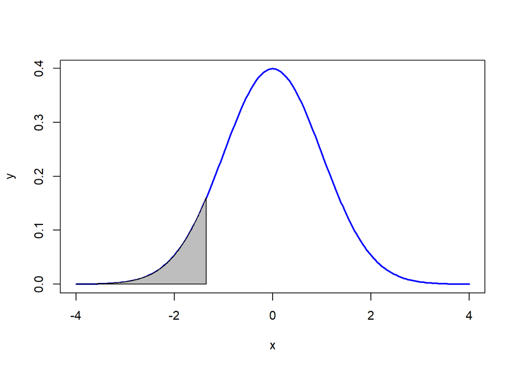

```r
#A
x=seq(-4,4,length=200)
y=dnorm(x)
plot(x,y,type="l", lwd=2, col="blue")
x=seq(-4,-1.35,length=200)
y=dnorm(x)
polygon(c(-4,x,-1.35),c(0,y,0),col="gray")
```

```r
pnorm(-1.35)
```

```
## [1] 0.08850799
```

[figure not shown]

```r
#B
x=seq(-4,4,length=200)
y=dnorm(x)
plot(x,y,type="l", lwd=2, col="blue")
x=seq(-4,1.48,length=200)
y=dnorm(x)
polygon(c(-4,x,1.48),c(0,y,0),col="gray")
```

```r
pnorm(1.48)
```

```
## [1] 0.9305634
```

[figure not shown]

```r
#C
x=seq(-4,4,length=200)
y=dnorm(x)
plot(x,y,type="l", lwd=2, col="blue")
x=seq(-4,1-pnorm(1.15)-pnorm(-.04),length=200)
y=dnorm(x)
polygon(c(-4,x,1-pnorm(1.15)-pnorm(-.04)),c(0,y,0),col="gray")
```

```r
pnorm(1.15)-pnorm(-.04)
```

```
## [1] 0.3908815
```

[figure not shown]

```r
#D
x=seq(-4,4,length=200)
y=dnorm(x)
plot(x,y,type="l", lwd=2, col="blue")
x=seq(-4,2,length=200)
y=dnorm(x)
polygon(c(-4,x,2),c(0,y,0),col="gray")
```

```r
pnorm(2)
```

```
## [1] 0.9772499
```

3.3 GRE scores, Part I. Sophia who took the Graduate Record Examination (GRE) scored 160 on the Verbal Reasoning section and 157 on the Quantitative Reasoning section. The mean score for Verbal Reasoning section for all test takers was 151 with a standard deviation of 7, and the mean score for the Quantitative Reasoning was 153 with a standard deviation of 7.67. Suppose that both distributions are nearly normal. (a) Write down the short-hand for these two normal distributions.

```r
#A
vs <- 160
qs <- 157
vmn <-151
vsd<-7
qmn<-153
qsd<-7.67
(vs-vmn)/vsd
```

```
## [1] 1.285714
```

```r
(qs-qmn)/qsd
```

```
## [1] 0.5215124
```

2. What is Sophia’s Z-score on the Verbal Reasoning section? On the Quantitative Reasoning section? Draw a standard normal distribution curve and mark these two Z-scores.

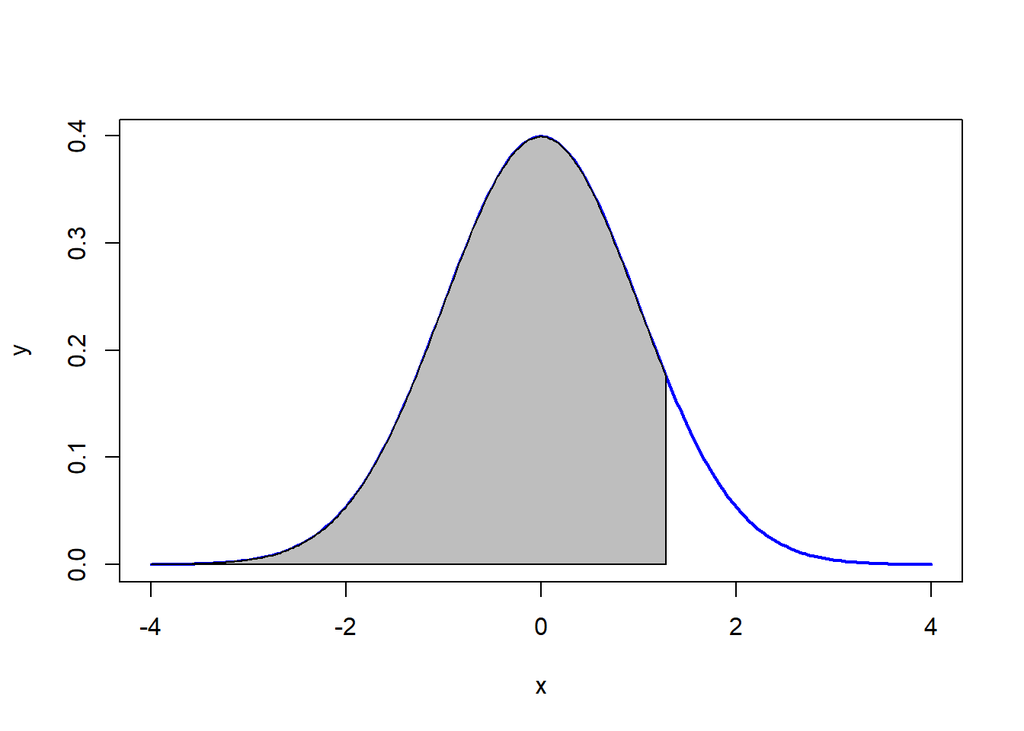

```r
#B
x=seq(-4,4,length=200)
y=dnorm(x)
plot(x,y,type="l", lwd=2, col="blue")
x=seq(-4,qnorm(pnorm(vs, vmn, vsd)),length=200)
y=dnorm(x)
polygon(c(-4,x,qnorm(pnorm(vs, vmn, vsd))),c(0,y,0),col="gray")
```

```r
qnorm(pnorm(vs, vmn, vsd))
```

```
## [1] 1.285714
```

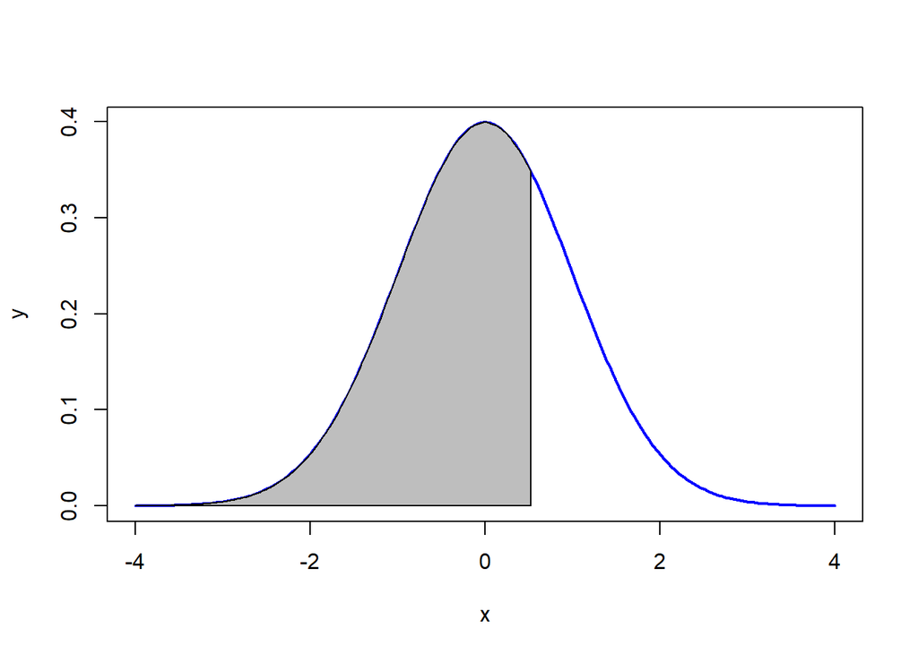

```r
x=seq(-4,4,length=200)
y=dnorm(x)
plot(x,y,type="l", lwd=2, col="blue")
x=seq(-4,qnorm(pnorm(qs, qmn, qsd)),length=200)
y=dnorm(x)
polygon(c(-4,x,qnorm(pnorm(qs, qmn, qsd))),c(0,y,0),col="gray")
```

```r
qnorm(pnorm(qs, qmn, qsd))
```

```
## [1] 0.5215124
```

3. What do these Z-scores tell you?

Zscore gives us scores are within 1-2 STD of mean.

4. Relative to others, which section did she do better on?

She does better in the Verbal reasoning as she did beter than 90 of others.

5. Find her percentile scores for the two exams.

```r
pnorm(vs, vmn, vsd)
```

```
## [1] 0.9007286
```

```r
pnorm(qs, qmn, qsd)
```

```
## [1] 0.6989951
```

6. What percent of the test takers did better than her on the Verbal Reasoning section? On the Quantitative Reasoning section?

```r
1-pnorm(vs, vmn, vsd)
```

```
## [1] 0.0992714
```

```r
1-pnorm(qs, qmn, qsd)
```

```
## [1] 0.3010049
```

7. Explain why simply comparing raw scores from the two sections could lead to an incorrect conclusion as to which section a student did better on.

When not comparing the others, you dont know if there were big differences in scores from 1 person to another. There may be an underlying reason for it that does not show in the numbers.

8. If the distributions of the scores on these exams are not nearly normal, would your answers to parts (b) - (f) change? Explain your reasoning.

Yes , mean/SD and z scores only apply to evenly distributed numbers.

1. The mean score is 77.7 points. with a standard deviation of 8.44 points. Use this information to determine if the scores approximately follow the 68-95-99.7% Rule.

```r
mn <- 77.7
sdd<- 8.44
sd1<- mn+sdd
sd2<- mn+sdd*2
sd1m<-mn-sdd
sd2m<-mn-sdd*2
sd1
```

```
## [1] 86.14
```

```r
sd2
```

```
## [1] 94.58
```

```r
sd1m
```

```
## [1] 69.26
```

```r
sd2m
```

```
## [1] 60.82
```

3.21 Married women. The 2010 American Community Survey estimates that 47.1% of women ages 15 years and over are married.48

1. We randomly select three women between these ages. What is the probability that the third woman selected is the only one who is married?
2. What is the probability that all three randomly selected women are married?
3. On average, how many women would you expect to sample before selecting a married woman? What is the standard deviation?
4. If the proportion of married women was actually 30%, how many women would you expect to sample before selecting a married woman? What is the standard deviation?
5. Based on your answers to parts (c) and (d), how does decreasing the probability of an event a???ect the mean and standard deviation of the wait time until success?

3.37 Exploring permutations. The formula for the number of ways to arrange n objects is n! = n×(n???1)×···×2×1. This exercise walks you through the derivation of this formula for a couple of special cases. A small company has ???ve employees: Anna, Ben, Carl, Damian, and Eddy. There are ???ve parking spots in a row at the company, none of which are assigned, and each day the employees pull into a random parking spot. That is, all possible orderings of the cars in the row of spots are equally likely.

1. On a given day, what is the probability that the employees park in alphabetical order?
2. If the alphabetical order has an equal chance of occurring relative to all other possible orderings, how many ways must there be to arrange the ???ve cars?
3. Now consider a sample of 8 employees instead. How many possible ways are there to order these 8 employees’ cars?

3.41 Sampling at school. For a sociology class project you are asked to conduct a survey on 20 students at your school. You decide to stand outside of your dorm’s cafeteria and conduct the survey on a random sample of 20 students leaving the cafeteria after dinner one evening. Your dorm is comprised of 45% males and 55% females.